# PGA Tour Data Analysis

Sam Freis

03/29/2023

## Analyzing and visualizing PGA tour data from 2015-2022

#### Data Import

```r
# data pulled from: https://www.advancedsportsanalytics.com/pga-overview

# Reading in Data
pga <- read_csv("ASA All PGA Raw Data - Tourn Level2015.csv", na = c("", "NA", "999"))
```

#### Basic data cleaning and looking at descriptives

```r
# look at var names and info
#names(pga)
#str(pga)
#head(pga)

# drop the empty variables
pga$`Unnamed: 2`<-NULL
pga$`Unnamed: 3`<-NULL
pga$`Unnamed: 4`<-NULL

# look for other NAs
pga[rowSums(is.na(pga))==0,]
```

```
## # A tibble: 17,008 × 34
##    Player_init…¹ tourn…² playe…³ hole_…⁴ strokes hole_…⁵ hole_…⁶ hole_…⁷ strea…⁸
##    <chr>           <dbl>   <dbl>   <dbl>   <dbl>   <dbl>   <dbl>   <dbl>   <dbl>
##  1 A. Hadwin      4.01e8    5548     284     283    57      51.3      62       0
##  2 A. Noren       4.01e8    3832     284     285    47      43.3      62       3
##  3 A. Putnam      4.01e8    5502     284     279    65      61.1      66       3
##  4 A. Scott       4.01e8     388     284     274    77.5    72.7      75       0
##  5 A. Smalley     4.01e8    9484     284     283    59.5    54        59       3
##  6 A. Wise        4.01e8   10577     284     277    70.5    64.4      73       3
##  7 B. Harman      4.01e8    1225     284     282    57.5    53.3      63       0
##  8 B. Horschel    4.01e8    1651     284     282    56      52.2      64       0
##  9 B. Steele      4.01e8    3596     284     281    60.5    55.4      65       3
## 10 C. Bezuidenh…  4.01e8    9243     284     276    68      65.6      72       6
## # … with 16,998 more rows, 25 more variables: streak_FDP <dbl>,
## #   streak_SDP <dbl>, n_rounds <dbl>, made_cut <dbl>, pos <dbl>,
## #   finish_DKP <dbl>, finish_FDP <dbl>, finish_SDP <dbl>, total_DKP <dbl>,
## #   total_FDP <dbl>, total_SDP <dbl>, player <chr>, `tournament name` <chr>,
## #   course <chr>, date <date>, purse <dbl>, season <dbl>, no_cut <dbl>,
## #   Finish <chr>, sg_putt <dbl>, sg_arg <dbl>, sg_app <dbl>, sg_ott <dbl>,
## #   sg_t2g <dbl>, sg_total <dbl>, and abbreviated variable names …
```

```r
# subset to numeric vars and describe
numVARS<-c("hole_par",
          "strokes",
          "hole_DKP",
          "hole_FDP",
          "hole_SDP",
          "streak_DKP",
          "streak_FDP",
          "streak_SDP",
          "pos",
          "finish_DKP",
          "finish_FDP",
          "finish_SDP",
          "total_DKP",
          "total_FDP",
          "total_SDP",
          "sg_putt",
          "sg_arg",
          "sg_app",
          "sg_ott",
          "sg_t2g",
          "sg_total"
)
numITEMS<-pga[numVARS]

numITEMS %>%
  summarise(across(everything(), ~ sum(is.na(.x))))
```

```
## # A tibble: 1 × 21
##   hole_par strokes hole_…¹ hole_…² hole_…³ strea…⁴ strea…⁵ strea…⁶   pos finis…⁷
##      <int>   <int>   <int>   <int>   <int>   <int>   <int>   <int> <int>   <int>
## 1        0       0       0       0       0       0       0       0 16169       0
## # … with 11 more variables: finish_FDP <int>, finish_SDP <int>,
## #   total_DKP <int>, total_FDP <int>, total_SDP <int>, sg_putt <int>,
## #   sg_arg <int>, sg_app <int>, sg_ott <int>, sg_t2g <int>, sg_total <int>, and
## #   abbreviated variable names ¹hole_DKP, ²hole_FDP, ³hole_SDP, ⁴streak_DKP,
## #   ⁵streak_FDP, ⁶streak_SDP, ⁷finish_DKP
```

```r
pga<-pga %>%
  filter_at(vars(sg_putt, sg_arg, sg_app, sg_ott, sg_t2g, sg_total), all_vars(!is.na(.)))

numITEMS<-numITEMS %>%
  filter_at(vars(sg_putt, sg_arg, sg_app, sg_ott, sg_t2g, sg_total), all_vars(!is.na(.)))

kable(describe(numITEMS),
      format='markdown',
      digits=3)
```

|  | vars | n | mean | sd | median | trimmed | mad | min | max | range | skew | kurtosis | se |
| --- | --- | --- | --- | --- | --- | --- | --- | --- | --- | --- | --- | --- | --- |
| hole_par | 1 | 30497 | 222.686 | 70.548 | 280.00 | 225.546 | 11.861 | 70.00 | 292.00 | 222.00 | -0.314 | -1.794 | 0.404 |
| strokes | 2 | 30497 | 221.278 | 66.936 | 271.00 | 223.443 | 26.687 | 66.00 | 313.00 | 247.00 | -0.306 | -1.762 | 0.383 |
| hole_DKP | 3 | 30497 | 49.505 | 24.115 | 52.00 | 48.762 | 32.617 | -2.50 | 174.00 | 176.50 | 0.255 | -0.647 | 0.138 |
| hole_FDP | 4 | 30497 | 43.820 | 24.175 | 44.40 | 43.167 | 31.283 | -21.40 | 134.70 | 156.10 | 0.185 | -0.995 | 0.138 |
| hole_SDP | 5 | 30497 | 48.723 | 22.281 | 54.00 | 48.799 | 31.135 | -11.00 | 107.00 | 118.00 | -0.066 | -1.412 | 0.128 |
| streak_DKP | 6 | 30497 | 1.724 | 2.824 | 0.00 | 1.112 | 0.000 | 0.00 | 23.00 | 23.00 | 2.089 | 5.242 | 0.016 |
| streak_FDP | 7 | 30497 | 7.550 | 7.214 | 6.40 | 6.612 | 8.303 | 0.00 | 43.60 | 43.60 | 0.937 | 0.276 | 0.041 |
| streak_SDP | 8 | 30497 | 1.633 | 2.629 | 0.00 | 1.058 | 0.000 | 0.00 | 22.00 | 22.00 | 1.867 | 3.989 | 0.015 |
| pos | 9 | 17008 | 34.141 | 21.398 | 32.00 | 33.428 | 26.687 | 1.00 | 91.00 | 90.00 | 0.225 | -1.080 | 0.164 |
| finish_DKP | 10 | 30497 | 2.362 | 4.725 | 0.00 | 1.196 | 0.000 | 0.00 | 30.00 | 30.00 | 3.138 | 11.564 | 0.027 |
| finish_FDP | 11 | 30497 | 2.021 | 4.664 | 0.00 | 0.810 | 0.000 | 0.00 | 30.00 | 30.00 | 3.430 | 13.268 | 0.027 |
| finish_SDP | 12 | 30497 | 1.107 | 2.823 | 0.00 | 0.307 | 0.000 | 0.00 | 15.00 | 15.00 | 3.097 | 9.362 | 0.016 |
| total_DKP | 13 | 30497 | 53.592 | 28.903 | 54.00 | 51.664 | 37.065 | -2.50 | 205.50 | 208.00 | 0.501 | -0.342 | 0.166 |
| total_FDP | 14 | 30497 | 53.391 | 33.321 | 49.90 | 51.092 | 39.289 | -21.40 | 202.60 | 224.00 | 0.525 | -0.448 | 0.191 |
| total_SDP | 15 | 30497 | 51.463 | 25.324 | 55.00 | 50.652 | 35.582 | -11.00 | 141.00 | 152.00 | 0.165 | -1.103 | 0.145 |
| sg_putt | 16 | 30497 | -0.120 | 1.118 | -0.04 | -0.075 | 1.038 | -5.99 | 4.43 | 10.42 | -0.449 | 0.809 | 0.006 |
| sg_arg | 17 | 30497 | -0.040 | 0.725 | 0.00 | -0.015 | 0.638 | -6.43 | 3.17 | 9.60 | -0.509 | 1.962 | 0.004 |
| sg_app | 18 | 30497 | -0.100 | 1.115 | 0.00 | -0.045 | 1.023 | -9.25 | 4.67 | 13.92 | -0.608 | 1.418 | 0.006 |
| sg_ott | 19 | 30497 | -0.045 | 0.809 | 0.05 | 0.015 | 0.697 | -7.74 | 2.77 | 10.51 | -1.149 | 3.739 | 0.005 |
| sg_t2g | 20 | 30497 | -0.184 | 1.636 | -0.01 | -0.080 | 1.468 | -13.95 | 6.30 | 20.25 | -0.814 | 1.784 | 0.009 |
| sg_total | 21 | 30497 | -0.301 | 1.961 | -0.16 | -0.187 | 1.794 | -13.67 | 8.52 | 22.19 | -0.714 | 1.432 | 0.011 |

## Research Questions:

### 1. Who appeared in the most tournaments since 2015?

#### 1a. What is the average number of tournament appearances?

```r
# count players' appearances
app<-as.data.frame(table(pga$Player_initial_last))
app<-app[ order(-app$Freq), ]
head(app)
```

```
##           Var1 Freq
## 70   B. Stuard  182
## 432    T. Hoge  175
## 126     D. Lee  174
## 320  N. Taylor  173
## 51   B. Harman  171
## 440 T. Merritt  169
```

```r
kable(describe(app$Freq), format='markdown',
      digits=3)
```

|  | vars | n | mean | sd | median | trimmed | mad | min | max | range | skew | kurtosis | se |
| --- | --- | --- | --- | --- | --- | --- | --- | --- | --- | --- | --- | --- | --- |
| X1 | 1 | 482 | 63.272 | 50.861 | 56.5 | 59.764 | 65.976 | 1 | 182 | 181 | 0.384 | -1.114 | 2.317 |

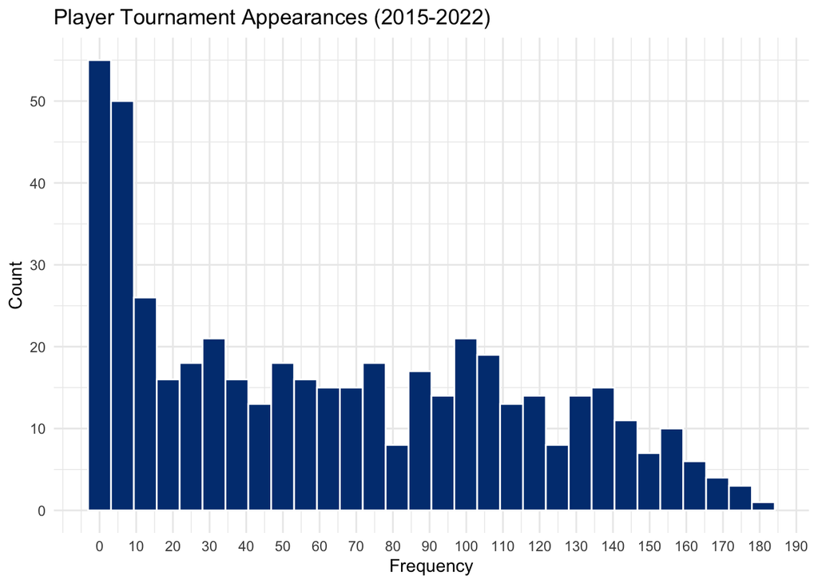

```r
ggplot(app, aes(x=Freq))+
  geom_histogram(color="#FFFFFF", fill="#003C80")+
  scale_x_continuous(breaks = seq(0, 200, by = 10))+
  scale_y_continuous(breaks = seq(0, 90, len = 10))+
  labs(title="Player Tournament Appearances (2015-2022)",x="Frequency", y = "Count")+
  theme_minimal()
```

Brian Stuard appeared in the most PGA tournaments from 2015-2022. The average number of tournaments played in was 63. Many players performed in fewer than 20 tournaments.

### 2. Who won the most tournaments since 2015?

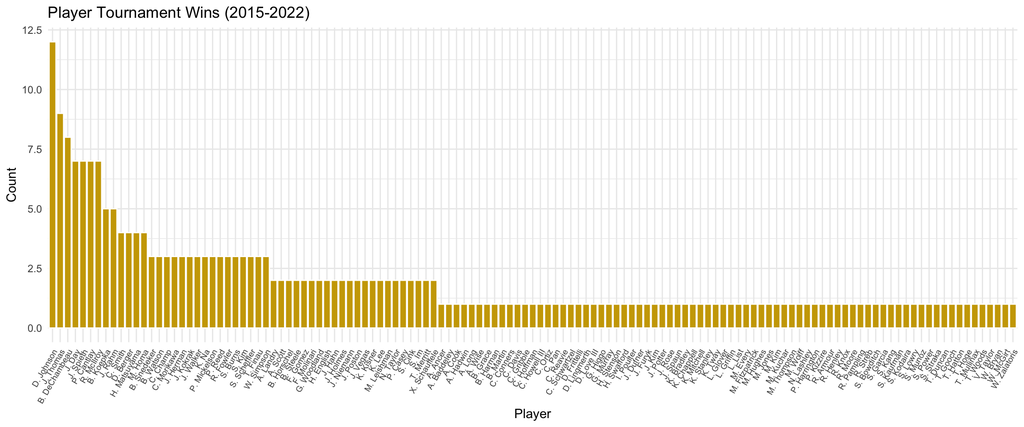

```r
winners <- pga[ which(pga$pos==1), ]

wincount<-winners %>% count(Player_initial_last)
wincount<-wincount[ order(-wincount$n), ]

ggplot(winners, aes(x = fct_infreq(Player_initial_last)))+
  geom_bar(color="#FFFFFF", fill="#CCA600")+
  labs(title="Player Tournament Wins (2015-2022)",x="Player", y = "Count")+
  theme_minimal()+
  theme(legend.position = "bottom", axis.text.x = element_text(angle=60, size=7, hjust = 1))
```

#### 2a. How have wins changed over time?

```r
library(gghighlight)
library(plotly)
winby<-as.data.frame(table(winners$Player_initial_last, winners$season))

winby <- winby %>%
       rename("player" = "Var1",
              "season" = "Var2",
              "wins" = "Freq")

p2 <- winby %>%
  ggplot(aes(x = season, y = wins, group = player)) +
  labs(x= "Season", y= "Wins") +
  ggtitle("Tournament Wins Over Time") +
  geom_line() +
  gghighlight(player == "R. McIlroy")+
  theme_minimal()
```

```
## label_key: player
```

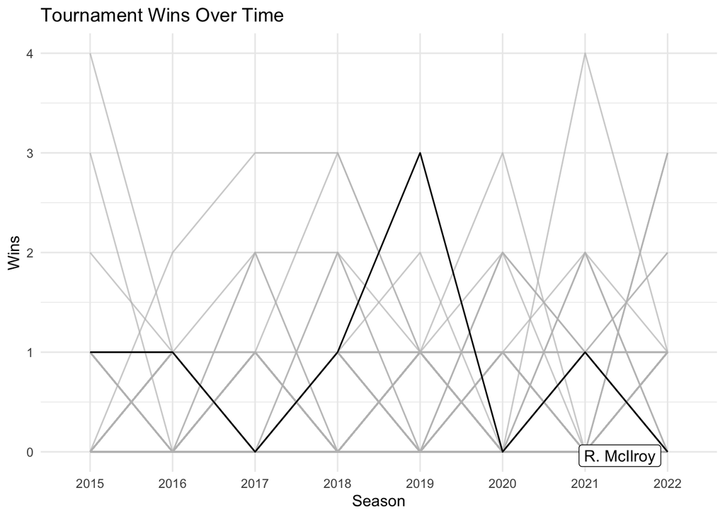

```r
p2
```

### 3. Examining max streak DKP, FDP and SDP (fantasy golf / sports betting data)

```r
streakVARS<-c(
           "streak_DKP",
           "streak_FDP",
           "streak_SDP"
)
streakITEMS<-pga[streakVARS]
kable(describe(streakITEMS), format='markdown',
      digits=3)
```

|  | vars | n | mean | sd | median | trimmed | mad | min | max | range | skew | kurtosis | se |
| --- | --- | --- | --- | --- | --- | --- | --- | --- | --- | --- | --- | --- | --- |
| streak_DKP | 1 | 30497 | 1.724 | 2.824 | 0.0 | 1.112 | 0.000 | 0 | 23.0 | 23.0 | 2.089 | 5.242 | 0.016 |
| streak_FDP | 2 | 30497 | 7.550 | 7.214 | 6.4 | 6.612 | 8.303 | 0 | 43.6 | 43.6 | 0.937 | 0.276 | 0.041 |
| streak_SDP | 3 | 30497 | 1.633 | 2.629 | 0.0 | 1.058 | 0.000 | 0 | 22.0 | 22.0 | 1.867 | 3.989 | 0.015 |

### 4. Information on strokes and strokes gained

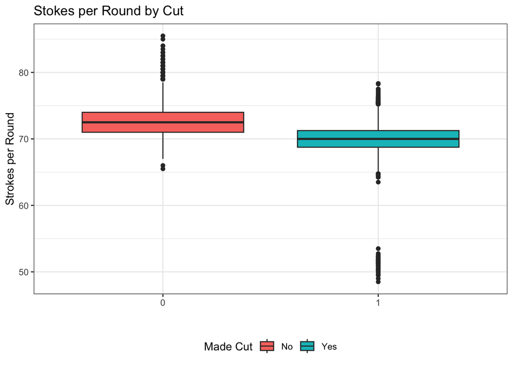

```r
## plot by cut
## scale strokes by round
pga$strokesperround<-(pga$strokes/pga$n_rounds)
pga$made_cut<-as.factor(pga$made_cut)

ggplot(pga, aes(x=made_cut, y=strokesperround, fill=made_cut)) +
  geom_boxplot()+
  theme_bw()+
  labs(title="Stokes per Round by Cut", y = "Strokes per Round", x = "")+
  scale_fill_discrete(name = "Made Cut", labels = c("No", "Yes"))+
  theme(legend.position="bottom")
```

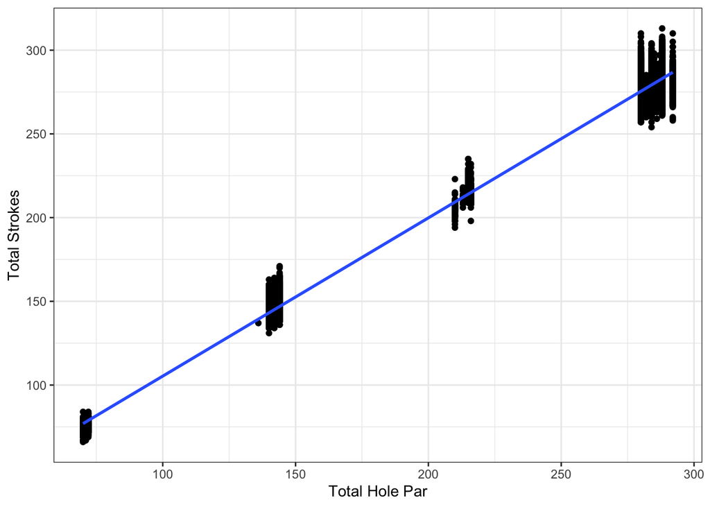

```r
## strokes and par
ggplot(pga, aes(x=hole_par, y=strokes)) +
  geom_point()+
  geom_smooth(method=lm)+
  labs(y = "Total Strokes", x = "Total Hole Par")+
  theme_bw()
```

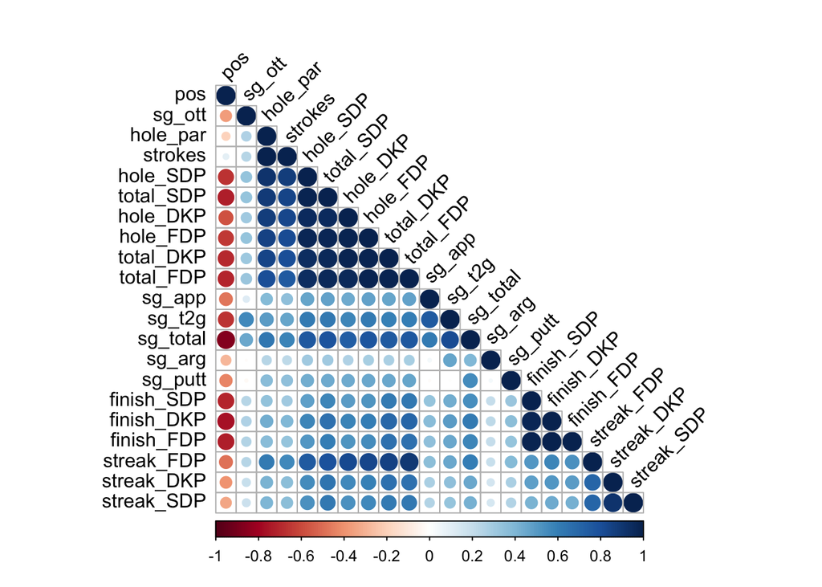

```r
## correlation matrix of numeric items
res <- cor(numITEMS, use="pairwise.complete.obs")
library(corrplot)
corrplot(res, type = "lower", order = "hclust",
         tl.col = "black", tl.srt = 45)
```

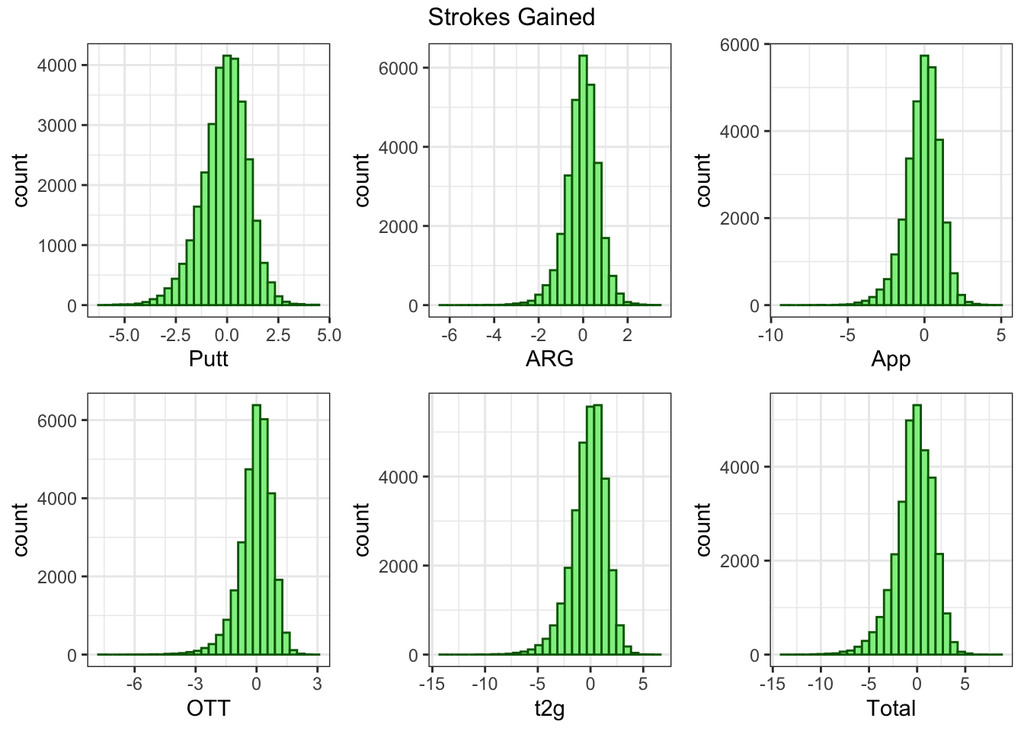

```r
# distributions of strokes gained
p1<-ggplot(pga, aes(sg_putt))+
  geom_histogram(color="darkgreen", fill="lightgreen")+
  labs(x="Putt")+
  theme_bw()

p2<-ggplot(pga, aes(sg_arg))+
  geom_histogram(color="darkgreen", fill="lightgreen")+
  labs(x="ARG")+
  theme_bw()

p3<-ggplot(pga, aes(sg_app))+
  geom_histogram(color="darkgreen", fill="lightgreen")+
  labs(x="App")+
  theme_bw()

p4<-ggplot(pga, aes(sg_ott))+
  geom_histogram(color="darkgreen", fill="lightgreen")+
  labs(x="OTT")+
  theme_bw()

p5<-ggplot(pga, aes(sg_t2g))+
  geom_histogram(color="darkgreen", fill="lightgreen")+
  labs(x="t2g")+
  theme_bw()

p6<-ggplot(pga, aes(sg_total))+
  geom_histogram(color="darkgreen", fill="lightgreen")+
  labs(x="Total")+
  theme_bw()

library(gridExtra)
grid.arrange(p1, p2, p3, p4, p5, p6, nrow = 2,
             top = "Strokes Gained"
)
```

```r
sgVARS<-c(
           "strokes",
           "pos",
           "sg_putt",
           "sg_arg",
           "sg_app",
           "sg_ott",
           "sg_t2g",
           "sg_total"

)
sgITEMS<-pga[sgVARS]
kable(describe(sgITEMS), format='markdown',
      digits=3)
```

|  | vars | n | mean | sd | median | trimmed | mad | min | max | range | skew | kurtosis | se |
| --- | --- | --- | --- | --- | --- | --- | --- | --- | --- | --- | --- | --- | --- |
| strokes | 1 | 30497 | 221.278 | 66.936 | 271.00 | 223.443 | 26.687 | 66.00 | 313.00 | 247.00 | -0.306 | -1.762 | 0.383 |
| pos | 2 | 17008 | 34.141 | 21.398 | 32.00 | 33.428 | 26.687 | 1.00 | 91.00 | 90.00 | 0.225 | -1.080 | 0.164 |
| sg_putt | 3 | 30497 | -0.120 | 1.118 | -0.04 | -0.075 | 1.038 | -5.99 | 4.43 | 10.42 | -0.449 | 0.809 | 0.006 |
| sg_arg | 4 | 30497 | -0.040 | 0.725 | 0.00 | -0.015 | 0.638 | -6.43 | 3.17 | 9.60 | -0.509 | 1.962 | 0.004 |
| sg_app | 5 | 30497 | -0.100 | 1.115 | 0.00 | -0.045 | 1.023 | -9.25 | 4.67 | 13.92 | -0.608 | 1.418 | 0.006 |
| sg_ott | 6 | 30497 | -0.045 | 0.809 | 0.05 | 0.015 | 0.697 | -7.74 | 2.77 | 10.51 | -1.149 | 3.739 | 0.005 |
| sg_t2g | 7 | 30497 | -0.184 | 1.636 | -0.01 | -0.080 | 1.468 | -13.95 | 6.30 | 20.25 | -0.814 | 1.784 | 0.009 |
| sg_total | 8 | 30497 | -0.301 | 1.961 | -0.16 | -0.187 | 1.794 | -13.67 | 8.52 | 22.19 | -0.714 | 1.432 | 0.011 |

```r
res2 <- cor(sgITEMS, use="pairwise.complete.obs")
round(res2, 2)
```

```
##          strokes   pos sg_putt sg_arg sg_app sg_ott sg_t2g sg_total
## strokes     1.00  0.09    0.35   0.23   0.35   0.24   0.46     0.59
## pos         0.09  1.00   -0.43  -0.29  -0.48  -0.37  -0.67    -0.86
## sg_putt     0.35 -0.43    1.00   0.03  -0.01  -0.03  -0.01     0.55
## sg_arg      0.23 -0.29    0.03   1.00   0.04  -0.01   0.46     0.40
## sg_app      0.35 -0.48   -0.01   0.04   1.00   0.11   0.75     0.61
## sg_ott      0.24 -0.37   -0.03  -0.01   0.11   1.00   0.57     0.45
## sg_t2g      0.46 -0.67   -0.01   0.46   0.75   0.57   1.00     0.82
## sg_total    0.59 -0.86    0.55   0.40   0.61   0.45   0.82     1.00
```

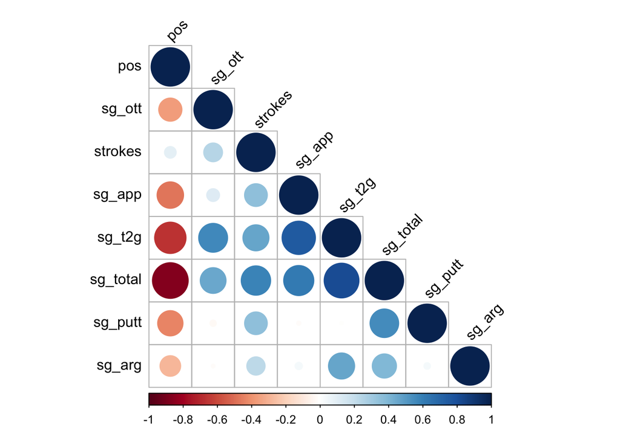

```r
library(corrplot)
corrplot(res2, type = "lower", order = "hclust",
         tl.col = "black", tl.srt = 45)
```

Strokes gained total and tee-to-green are sums of other strokes gained categories.

###### 4b. Strokes gained predicting position

```r
library(sjPlot)
pga$playerid<-as.factor(pga$`player id`)
pga$tourid<-as.factor(pga$`tournament id`)

m1<- lmer(pos ~ sg_ott+sg_app+sg_arg+sg_putt+(1|playerid), data=pga)
#summary(m1)
tab_model(m1)
```

|  | pos |  |  |
| --- | --- | --- | --- |
| Predictors | Estimates | CI | p |
| (Intercept) | 45.10 | 44.76 – 45.43 | **<0.001** |
| sg ott | -13.21 | -13.50 – -12.93 | **<0.001** |
| sg app | -13.09 | -13.28 – -12.89 | **<0.001** |
| sg arg | -13.41 | -13.71 – -13.12 | **<0.001** |
| sg putt | -13.59 | -13.78 – -13.39 | **<0.001** |
| Random Effects |  |  |  |
| σ<sup>2</sup> | 112.47 |  |  |
| τ<sub>00</sub> <sub>playerid</sub> | 6.75 |  |  |
| ICC | 0.06 |  |  |
| N <sub>playerid</sub> | 426 |  |  |
| Observations | 17008 |  |  |
| Marginal R<sup>2</sup> / Conditional R<sup>2</sup> | 0.731 / 0.746 |  |  |

```r
#check_model(m1)
#model_performance(m1)
```

The metric strokes gained was developed by Columbia business professor Mark Broadie and was a massive advancement in golf analytics: https://www8.gsb.columbia.edu/researcharchive/articles/4996. Strokes Gained measures the quality of each shot based on its starting and ending locations. So, calculations factor in the average number of shots for a golfer to get down from a given starting distance and starting lie condition and the average number of shots to get down from a given end distance and end lie condition. These average numbers are different for professional vs. amateur golfers. Negative numbers represent how many shots a golfer has lost compared to the benchmark, while positive numbers represent how many shots have been gained against said benchmark. Negative numbers highlight areas for improvement, while positive numbers indicate the golfer has performed well.

Additionally, the strokes gained categories were uncorrelated with each other indicating that they are independent. For example, strokes gained putting was not related to strokes gained on the approach. So, if a golfer is struggling in one area, that may be independent from performance in other areas.

After accounting for clustering within player, all categories of of strokes gained statistically predicted final position in players that made the cut.

Importantly, since only players that made the cut get a position, these relationships could change in the full sample. Let’s take a look at strokes gained predicting performance but with making the cut (yes/no) as the outcome.

```r
table(pga$made_cut)
```

```
##
##     0     1
## 12728 17769
```

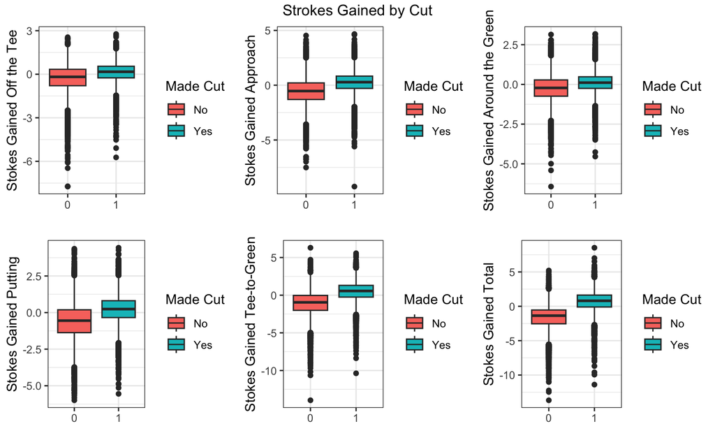

```r
p1<-ggplot(pga, aes(x=made_cut, y=sg_ott, fill=made_cut)) +
  geom_boxplot()+
  theme_bw()+
  labs(y = "Stokes Gained Off the Tee", x = "")+
  scale_fill_discrete(name = "Made Cut", labels = c("No", "Yes"))

p2<-ggplot(pga, aes(x=made_cut, y=sg_app, fill=made_cut)) +
  geom_boxplot()+
  theme_bw()+
  labs(y = "Stokes Gained Approach", x = "")+
  scale_fill_discrete(name = "Made Cut", labels = c("No", "Yes"))

p3<-ggplot(pga, aes(x=made_cut, y=sg_arg, fill=made_cut)) +
  geom_boxplot()+
  theme_bw()+
  labs(y = "Stokes Gained Around the Green", x = "")+
  scale_fill_discrete(name = "Made Cut", labels = c("No", "Yes"))

p4<-ggplot(pga, aes(x=made_cut, y=sg_putt, fill=made_cut)) +
  geom_boxplot()+
  theme_bw()+
  labs(y = "Stokes Gained Putting", x = "")+
  scale_fill_discrete(name = "Made Cut", labels = c("No", "Yes"))

p5<-ggplot(pga, aes(x=made_cut, y=sg_t2g, fill=made_cut)) +
  geom_boxplot()+
  theme_bw()+
  labs(y = "Stokes Gained Tee-to-Green", x = "")+
  scale_fill_discrete(name = "Made Cut", labels = c("No", "Yes"))

p6<-ggplot(pga, aes(x=made_cut, y=sg_total, fill=made_cut)) +
  geom_boxplot()+
  theme_bw()+
  labs(y = "Stokes Gained Total", x = "")+
  scale_fill_discrete(name = "Made Cut", labels = c("No", "Yes"))

library(gridExtra)
grid.arrange(p1, p2, p3, p4, p5, p6, nrow = 2,
             top = "Strokes Gained by Cut"
)
```

```r
quallogit <- glmer(made_cut ~ sg_ott+sg_app+sg_arg+sg_putt+(1|playerid), data = pga, family = "binomial", control = glmerControl(optimizer = "bobyqa"),
    nAGQ = 10)

print(quallogit, corr=FALSE)
```

```
## Generalized linear mixed model fit by maximum likelihood (Adaptive
##   Gauss-Hermite Quadrature, nAGQ = 10) [glmerMod]
##  Family: binomial  ( logit )
## Formula: made_cut ~ sg_ott + sg_app + sg_arg + sg_putt + (1 | playerid)
##    Data: pga
##       AIC       BIC    logLik  deviance  df.resid
##  26878.00  26927.95 -13433.00  26866.00     30491
## Random effects:
##  Groups   Name        Std.Dev.
##  playerid (Intercept) 0.2275
## Number of obs: 30497, groups:  playerid, 484
## Fixed Effects:
## (Intercept)       sg_ott       sg_app       sg_arg      sg_putt
##       0.765        1.029        1.097        1.084        1.175
```

```r
se <- sqrt(diag(vcov(quallogit)))
(tab <- cbind(Est = fixef(quallogit), LL = fixef(quallogit) - 1.96 * se, UL = fixef(quallogit) + 1.96 *
    se))
```

```
##                   Est        LL        UL
## (Intercept) 0.7650378 0.7243555 0.8057201
## sg_ott      1.0287229 0.9839140 1.0735319
## sg_app      1.0972083 1.0625877 1.1318289
## sg_arg      1.0839386 1.0370347 1.1308425
## sg_putt     1.1754451 1.1404674 1.2104228
```

```r
tab_model(quallogit)
```

|  | made cut |  |  |
| --- | --- | --- | --- |
| Predictors | Odds Ratios | CI | p |
| (Intercept) | 2.15 | 2.06 – 2.24 | **<0.001** |
| sg ott | 2.80 | 2.67 – 2.93 | **<0.001** |
| sg app | 3.00 | 2.89 – 3.10 | **<0.001** |
| sg arg | 2.96 | 2.82 – 3.10 | **<0.001** |
| sg putt | 3.24 | 3.13 – 3.35 | **<0.001** |
| Random Effects |  |  |  |
| σ<sup>2</sup> | 3.29 |  |  |
| τ<sub>00</sub> <sub>playerid</sub> | 0.05 |  |  |
| ICC | 0.02 |  |  |
| N <sub>playerid</sub> | 484 |  |  |
| Observations | 30497 |  |  |
| Marginal R<sup>2</sup> / Conditional R<sup>2</sup> | 0.589 / 0.595 |  |  |

Similar to the restricted sample, each category of strokes gained independently statistically predicted if player performance indexed by making the tournament cut. Higher strokes gained corresponded a better chance of making the tournament.